# Введение

Притчин Иван

13 мая 2018 г

### Основные определения

##### Генеральная совокупность. Выборка.

Генеральная совокупность - множество объектов, на которые мы бы хотели распространить выводы в рамках исследования некоторой проблемы. Часто объемы генеральной совокупности очень велики и нет возможности исселдовать каждый отдельный объект. Поэтому, из элементов генеральной совокупности создаётся выборка, являющаяся подмножеством элементов генеральной совокупности. Важным свойством является репрезентативность выборки. Мы хотим, чтобы выборка была моделью генальной совокупности. Существует несколько вариантов формирования.

###### Способы формирования выборки

- простая случайная выборка
- стратифицированная выборка - разбитие на страты(группы) и выбор значение из страт. Пример: деление на мужчин и женщин. И выбор набора элементов из каждой страты.
- групповая выборка - разбиение на похожие группы (кластеры), выбор набора групп. Выбор значений из каждой выбранной группы.

#### Типы переменных

- количественные
- непрерывные (рост)
- дискретные (количество детей в семье)
- номинативные (качественные) - используются для разделения наблюдений на группы (1 - мужской, 2 - женский). Сравнение номинативных переменных не имеет смысла.
- ранговые переменные (пример с финишом спортсменов - показывает порядок, но не отражает насколько быстрее или медленнее тот или иной спортсмен)

### Описательные статистики

#### Меры центральной тенденкции

Мода - значение измеряемого признака, которое встречается наиболее часто. Распределение может иметь моду, не иметь её и быть антимодальным.

Медиана - значение, которое разделяет упорядоченное множество данных пополам.

Среднее значение - сумма всех значений, деленная на число наблюдений. Свойство среднего.
$$M_{x+c} = {M_{x}+c}.$$
$$M_{x*c} = {M_{x}*c}.$$
$$\sum_{i=1}^{n}(x_{i}-M_{x})=0.$$
Вопрос: зачем нам три различных три меры центральных тенденций?

Если распределение симметрично, одномодально, не имеет выбросов - можно использовать любую меру центральной тенденции. Если имеется ассиметрия, заметные выбросы, несколько мод - рекомендуется использовать медиану или моду.

#### Меры изменчивости

Для описания разброса данных используются меры изменчивости. Размах - разница между максимальным и минимальным значением. Недостаток - оценка изменчивости только на крайних двух значениях.

Дисперсия - средний квадрат отклонений индивидуальных значений признака от средней величины. Для генеральной совокупности дисперсия находится следующим образом:
$$D=\frac{\sum_{i=1}^{n}(x_i-\overline{x})^2}{n}.$$
Для выборки:
$$D=\frac{\sum_{i=1}^{n}(x_i-\overline{x})^2}{n-1}.$$
Cвойства дисперсии
$$D_{x+c}=D_x$$
$$D_{x*c}=D_x*c^2$$

Среднее квадратическое отклонение (Обозначения: $\sigma$ - для генеральной совокупности, $sd$ - для выборки ) - квадратный корень из дисперсии.
$$\sigma = \sqrt{D}$$
$$sd_{x+c}=sd_x$$
$$sd_{x*c}=sd_x*c$$
#### Квантили распределения Квантили распределения - значения признака, которые деляет набор упорядоченных данных на некоторое количество равных частей Квартили распределения - три точки, делющие распределение на 4 равные части. Квартили распределения отображаются на графике boxplot.

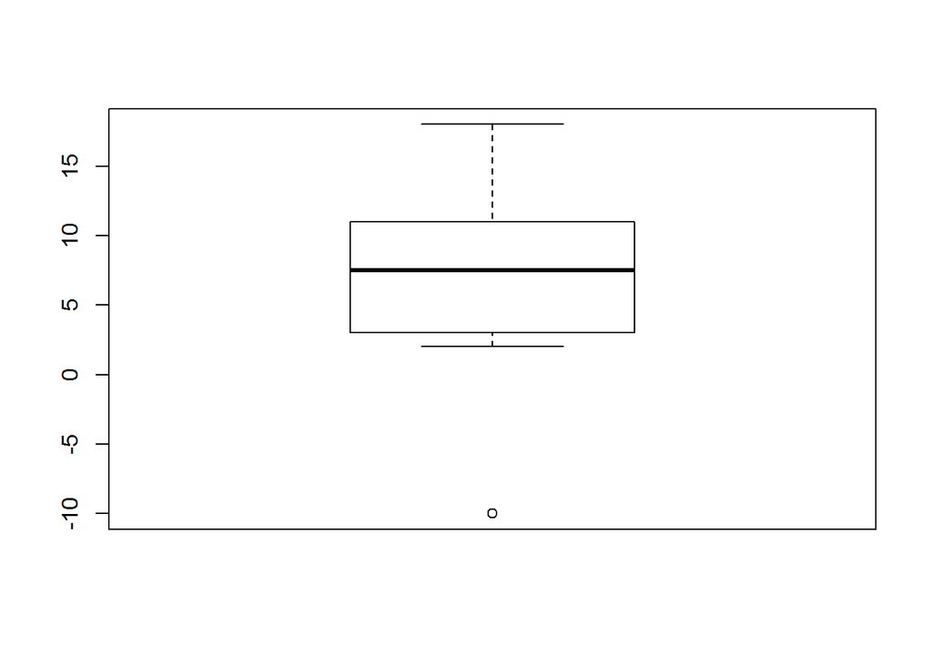

```r
x <- c(-10, 2, 2, 4, 6, 7, 8, 9, 11, 11, 11, 18)
boxplot(x)
```

Межквартильным размахом будем называть число, найденное как разницу значений между 3 и 1 квартилем распределения.

### Нормальное распределение

Большое число встречаемых в природе распределений являются нормальными. Например рост и вес человека. Встретить очень высокого и очень низкого человека примерно равновероятно.

Нормальное распределение  
- унимодально  
- симметрично - отклонение наблюдений от среднего подчиняются определенному вероятностному закону

Часто данных приходится стандартизировать.
Стандартизация (z-преобразование) - преобразование полученных данных в стандартную Z-шкалу со средним $M_z=0$, $D_z = 1$. В некотором смысле, для нас будет важно не сами единицы измерения x, сколько значение отклонения каждого наблюдения в стандартных отклонениях. Формула z-преобразования
$$x_z = \frac{x_i-\overline{x}}{\sigma}$$
Есть ряд полезных функций для работы с нормальным распределением

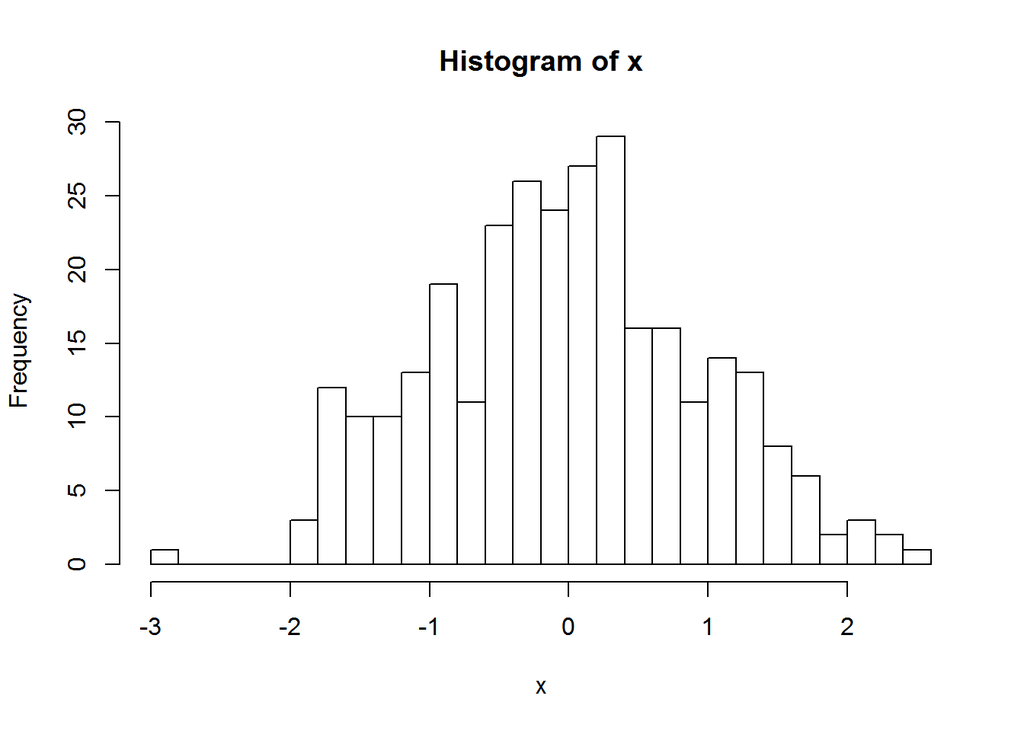

```r
# Генерация значений, распределенных по нормальному закону
x <- rnorm(300, mean = 0, sd = 1)
hist(x, breaks = 20)
```

```r
# Вероятность получить значение меньше заданного может быть найдена с помощью pnorm
pnorm(q = 1, mean = 0, sd = 1)
```

```
## [1] 0.8413447
```

#### Центральная предельная теорема.

Допустим, что некоторый признак распределен нормально. Будем многократно извлекать выборки из нашей генеральной совокупности и подсчитывать средние значения в каждом случае. Полученные значения также будут распределены некоторым образом. Полученное распределение будет нормальным а, стандартное отклонение полученного распределения называется стандартной ошибкой среднего.
$$se = \frac{\sigma}{\sqrt{n}}$$
##### Построение доверительных интервалов для средних значений Порой возникает задача, по выборочному среднему найти среднее генеральной совокупности. Точное значение получить невозможно, однако ЦПТ позволяет получить некоторый доверительный интервал. Напомним, что если бы мы собирали выборки из генеральной совокупности, находили среднее, и для него бы строили свой 95%-ый доверительный интервал (т.е среднее +- $1.96\sigma$), то в 95% случаев в доверительный интервал попадало и среднее генеральной совокупности.

Рассмотрим на примере Пусть $sd=4$, $\overline{X}=100$, $n=64$. Тогда
$$se=\frac{sd_x}{\sqrt{n}}=\frac{4}{\sqrt{64}}=0.5$$

$$left = \overline{X}-1.96*\sigma$$
А правая граница:
$$right= \overline{X}+1.96*\sigma$$
В нашем случае $left = 99.02$, $right = 100.98$.
Таким образом, мы можем сказать, что с 95% вероятностью, среднее генеральной совокупности лежит в промежутке $[99.02, 100.98]$

[Об интерпретации доверительных интервалах](http://thinkcognitive.org/ru/blog/golova-professora-bambldorfa)

#### Идея статистического вывода

Предположим, что на выздоровление больного от некоторой болезни x уходит 20 дней. На 64 испытуемых, выбранных из генеральной совокупности, мы протестировали лекарство. Средний срок выздоровления составил 18.5 дней, при среднем квадратическом отклонении равным 4. Вопрос: ускоренное выздоровление больных, это следствие применения лекарства или случайность. Введём ряд определений. Нулевая гипотеза - никакого воздействия препарат не оказывает т. е. $M_{нп}=20$ Альтернативная гипотеза - препарат влияет на скорость выздоровления ($M_{нп}!=20$). Выполним z-преобразование:
$$z = \frac{\overline{X}-M}{se} = -3$$
Видим, что среднее отклонилось на $-3\sigma$ в левую сторону. Оценим вероятность такого отклонения

```r
res <- pnorm(q = -3) + pnorm(q = 3, lower.tail = FALSE)
res
```

```
## [1] 0.002699796
```

Таким образом, мы можем сказать, что вероятность отклониться как в левую, так и в правую сторону на расстояние $3\sigma$ равняется 0.0026998.